# Trabalho em grupo mult1 parte_1_1

Enuncidado:

Grupo 05 - Siga as instruções em anexo.

Vetor de referência para o teste de hipótese:

Pressão sistólica média = 118;

Colesterol médio = 185;

Glicemia média = 92.

1. Análise descritiva inicial dos dados.

O primeiro integrante do grupo deverá apresentar uma descrição inicial da base de dados. Essa análise deve incluir:

(a) uma breve descrição do contexto da base de dados;

(b) identificação das variáveis quantitativas que serão utilizadas na análise;

(c) cálculo e interpretação do vetor de médias amostrais;

(d) cálculo e interpretação da matriz de variâncias e covariâncias amostral;

(e) cálculo e interpretação da matriz de correlações amostral;

(f) construção de gráficos adequados para visualizar o comportamento individual e conjunto das variáveis.

A interpretação deve destacar quais variáveis apresentam maior variabilidade, quais pares de variáveis parecem mais associados e se existem observações aparentemente discrepantes.

### *(a) uma breve descrição do contexto da base de dados;*

A base de dados referente ao trabalho é um arquivo .csv cujo nome é "saude" disponibilizado pelo Prof.Ricardo.

O arquivo contém 65 observações, e para cada observação são registradas 3 variáveis ("pressao_sistolica","colesterol","glicemia"), e são quantitativas.

Iremos usar ferramentas estatísticas (como teste de hipótese; intervalo de confiança) para analisar esses dados.

*Não temos informação disponível sobre quem é a população nesse contexto, nem unidades de medida das variáveis embora muito provavelmente sejam mmHg, mg/dL e mg/dL respectivamente.

### *(b) identificação das variáveis quantitativas que serão utilizadas na análise;*

A análise vai ser sobre as três variáveis disponíveis no arquivo: "pressao_sistolica","colesterol","glicemia"

Por conveniência vamos chamar variáveis de:

$X_1$: Nível da Pressão Sistólica

$X_2$: Nível do Colesterol

$X_1$: Nível da Glicemia

Assim, naturalmente $X_{1j}$ é a pressão sistólica referente à j-ésima observação da base, $X_{2j}$ é o colesterol referente à j-ésima observação assim por diante.

### *(c) cálculo e interpretação do vetor de médias amostrais;*

$\bar{X_1}$ = 118.612

$\bar{X_2}$ = 185.209

$\bar{X_3}$ = 93.165

Interpretação:

Com base na amostra observada, estima-se que:

1. a média da Pressão Sistólica da população do contexto seja de 118.612 unidades;
2. a média do Colesterol da população do contexto seja de 185.209 unidades;
3. a média da Glicemia da população do contexto seja de 93.165 unidades;

### *(d) cálculo e interpretação da matriz de variâncias e covariâncias amostral;*

A matriz de variâncias e covariâncias amostral é:

| Matriz VarCov | **Pressão Sistólica** | **Colesterol** | **Glicemia** |
| --- | --- | --- | --- |
| **Pressão Sistólica** | 133.399 | 128.877 | 36.293 |
| **Colesterol** | 128.877 | 322.028 | 75.331 |
| **Glicemia** | 36.293 | 75.331 | 80.389 |

Interpretação:

1. As variâncias não são comparáveis, pois as escalas das variáveis são diferentes:
- Pressão varia 84.64 até 144.78 unidades (amplitude = 60.14 unidades);
- Colesterol varia de 135.2 até 233.9 unidades (amplitude = 98.7 unidades).
- Glicemia varia 72.27 até 113.67 unidades (amplitude = 41.4 unidades);
2. As covariâncias amostrais são positivas, o que indica uma relação linear positiva entre as variáveis, i.e., as variáveis tendem a variar no mesmo sentido (se uma aumentar outras tendem a aumentar também, e se uma diminuir as outras tendem a diminuir).

### *(e) cálculo e interpretação da matriz de correlações amostral;*

A matriz de correlações amostral é:

| Matriz Corr | **Pressão Sistólica** | **Colesterol** | **Glicemia** |
| --- | --- | --- | --- |
| **Pressão Sistólica** | 1 | 0.622 | 0.350 |
| **Colesterol** | 0.622 | 1 | 0.468 |
| **Glicemia** | 0.350 | 0.468 | 1 |

Interpretação:

Dessa forma, há indicativos de que, na população estudada:

indivíduos com pressão sistólica maior tendem (moderadamente) a apresentar nível de colesterol mais alto; indivíduos com pressão sistólica maior tendem a apresentar nível de glicemia mais alto; indivíduos com nível de colesterol maior tendem a apresentar nível de glicemia mais alto;

### *(f) construção de gráficos adequados para visualizar o comportamento individual e conjunto das variáveis.*

[figure not shown]

```r
library(readxl)

dados <- read.csv("saude.csv")
```

```r
summary(dados)
```

```
 pressao_sistolica   colesterol       glicemia
 Min.   : 84.64    Min.   :135.2   Min.   : 72.27
 1st Qu.:112.75    1st Qu.:175.4   1st Qu.: 86.66
 Median :120.55    Median :183.8   Median : 94.00
 Mean   :118.61    Mean   :185.2   Mean   : 93.16
 3rd Qu.:124.69    3rd Qu.:195.7   3rd Qu.: 99.68
 Max.   :144.78    Max.   :233.9   Max.   :113.67
```

```r
colMeans(dados)
```

**pressao_sistolica**

118.611578375026

**colesterol**

185.209239579568

**glicemia**

93.1649883153215

```r
cov(dados)
```

A matrix: 3 × 3 of type dbl

|  | pressao_sistolica | colesterol | glicemia |
| --- | --- | --- | --- |
| pressao_sistolica | 133.39943 | 128.87702 | 36.29303 |
| colesterol | 128.87702 | 322.02807 | 75.33074 |
| glicemia | 36.29303 | 75.33074 | 80.38872 |

```r
cor(dados)
```

A matrix: 3 × 3 of type dbl

|  | pressao_sistolica | colesterol | glicemia |
| --- | --- | --- | --- |
| pressao_sistolica | 1.0000000 | 0.6218013 | 0.3504683 |
| colesterol | 0.6218013 | 1.0000000 | 0.4681961 |
| glicemia | 0.3504683 | 0.4681961 | 1.0000000 |

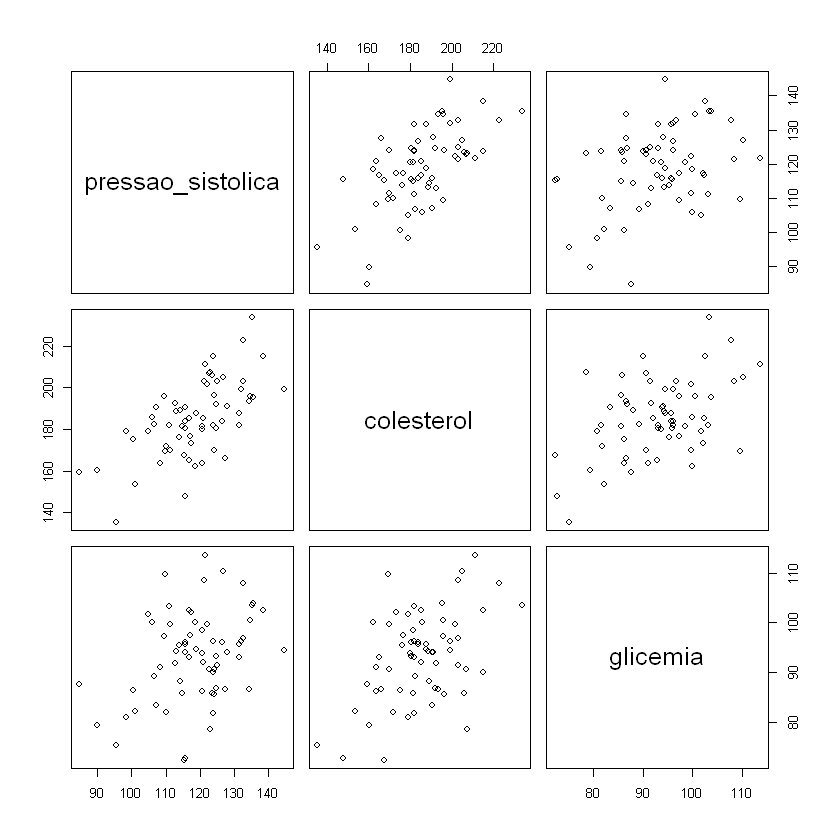

```r
pairs(dados)
```

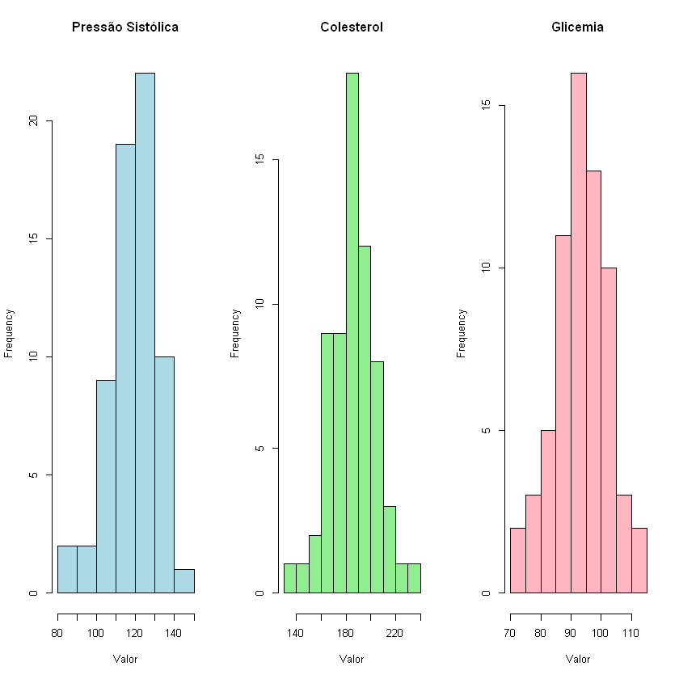

```r
par(mfrow = c(1, 3))

hist(dados$pressao_sistolica,
     main = "Pressão Sistólica",
     xlab = "Valor",
     col = "lightblue")

hist(dados$colesterol,
     main = "Colesterol",
     xlab = "Valor",
     col = "lightgreen")

hist(dados$glicemia,
     main = "Glicemia",
     xlab = "Valor",
     col = "lightpink")
```